# Various Plots and their uses

# 7. Correlation Matrices

### Utility

- **Purpose**: Visualise **pairwise correlations** between multiple numeric variables.
- **What to look for**: Strong positive (red) / negative (blue) relationships at a glance.
- **Best for**: Multicollinearity diagnosis in regression modelling, and initial feature selection.

### Implementation

Compute `cor()` on numeric columns, `melt()` into long format, then plot with a **diverging** colour scale (midpoint = 0).

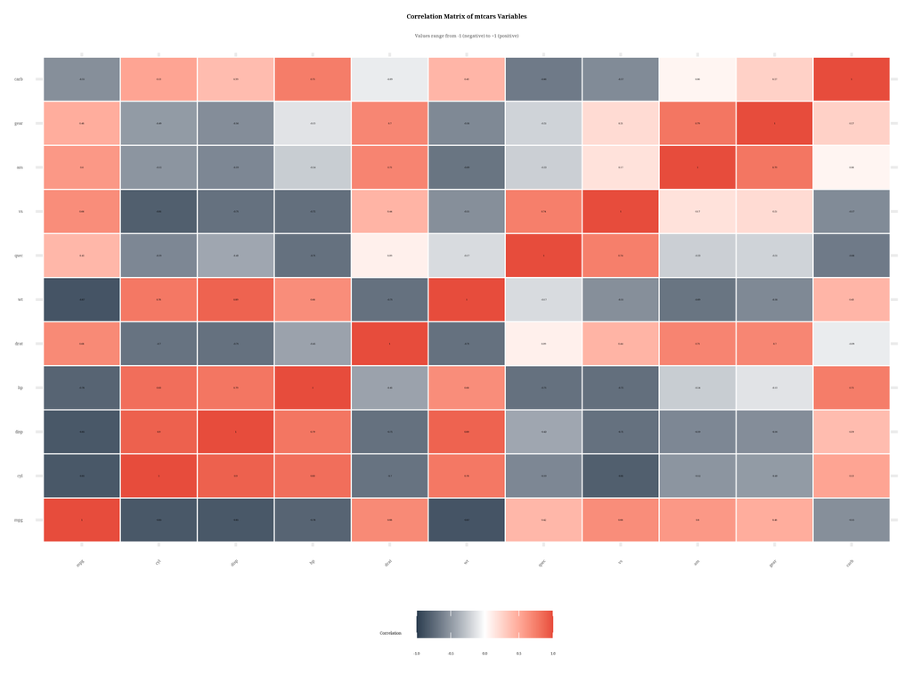

```r
corr_matrix <- round(cor(mtcars), 2)
corr_melt <- melt(corr_matrix, varnames = c("Var1", "Var2"))

ggplot(corr_melt, aes(x = Var1, y = Var2, fill = value)) +
  geom_tile(color = "white") +
  geom_text(aes(label = value), size = 3.5, color = "black") +
  scale_fill_gradient2(
    low = "#2c3e50",    # dark blue for negative
    mid = "white",      # zero
    high = "#e74c3c",   # red for positive
    midpoint = 0,
    limit = c(-1, 1),
    name = "Correlation"
  ) +
  labs(
    title = "Correlation Matrix of mtcars Variables",
    subtitle = "Values range from -1 (negative) to +1 (positive)"
  ) +
  theme(
    axis.text.x = element_text(angle = 45, hjust = 1),
    axis.title = element_blank()
  )
```

**Why diverging colours?** They make the sign and magnitude immediately obvious. `scale_fill_gradient2` is perfect for this.

# Quick Comparison Table

| Plot | Geom | Data Types | Primary Utility |
| --- | --- | --- | --- |
| **Scatter** | `geom_point()` | 2 continuous | Relationship, trends, clustering, outliers |
| **Histogram** | `geom_histogram()` | 1 continuous | Distribution shape, skewness, modality |
| **Density** | `geom_density()` | 1 continuous (+ fill groups) | Smoothed distribution, compare multiple groups |
| **Boxplot** | `geom_boxplot()` | 1 continuous + 1 categorical | Summarise and compare distributions (medians, IQR) |
| **Violin** | `geom_violin()` | 1 continuous + 1 categorical | Full distribution + summary for group comparisons |
| **Heatmap** | `geom_tile()` | 2 categorical (values) | Visualise 2-D aggregated metrics / patterns |
| **Correlation** | `geom_tile()` | Many numeric → matrix | Spot collinearity, feature relationships at scale |

# Conclusion

Mastering these seven visualisations covers **90%** of day-to-day exploratory data analysis needs. Remember the **layered** philosophy of ggplot2:

> *Data → Aesthetics → Geoms → Scales → Facets → Themes*

Start simple, then iteratively add labels, colors, and statistical layers to tell a compelling data story.